# Greenland turbot 2026 projections

Input audit and conditional projection results

Rendered

October 27, 2026

This working report audits the current input files and, when explicitly selected, reads a completed projection attempt. Rendering **never compiles or runs ADMB**. Conditional projections describe the supplied inputs and assumptions; they are not adopted catch recommendations.

## Run controls

From this directory, render the current input audit with:

```bash
quarto render greenland_turbot.qmd
```

The default selects no saved attempt, so this command works in a fresh source checkout and produces the audit without projection figures or tables.

To include results, set `saved_run` in the YAML above or pass the actual attempt directory explicitly. This example path is illustrative; the report never selects the newest directory automatically:

```bash
quarto render greenland_turbot.qmd -P saved_run:spmR_runs/attempt-001
```

```r
saved_run <- params$saved_run
worms_per_plot <- 15L
table_years <- 3L
```

### Start a new projection manually

Run this chunk yourself in R **after reviewing the input audit**. It is excluded from rendering. Keep `run_new_projections = FALSE` until the histories are complete. Supply verified population weights, units and ages, or explicitly choose the diagnostic assumptions with `use_diagnostic_weights = TRUE`. Diagnostic mode cannot repair missing history values. Work from `examples/gt_2026` in R.

```r
source("run.R")
run_new_projections <- FALSE
use_diagnostic_weights <- FALSE
population_weights <- NULL
units <- NULL
ages <- NULL

if (run_new_projections) {
  projection <- run_gt2026_projection(
    diagnostic = use_diagnostic_weights,
    population_weights = population_weights,
    units = units,
    ages = ages
  )
  projection$run_dir
}
```

After a successful run, use the returned directory as `saved_run` and render again. Each new run receives a separate attempt directory. Re-rendering reads saved outputs and preserves the attempt contents.

## Current status

**Saved conditional projection loaded.** No new projection was run.

Current recruitment and SSB lengths agree. Their calendar pairing and scientific declarations still require review.

Diagnostic population weights are fleet-weighted catch-weight proxies, not verified population body weights. SS3 export definitions, units, age order, plus group, initial abundance timing and spawning-weight/maturity definitions remain scientific review items. The audit below refers to **current files**; saved-run assumptions are displayed separately in the provenance section.

## Input audit

The current controls request 1000 simulations across 7 alternatives for 15 years, beginning in 2026.

Table 1: Current GT2026 input checks. Repair and review entries remain visible even when a saved run is selected.

| Input | Status | Finding |
| --- | --- | --- |
| Native metadata | info | A separate spm_input_v2.dat is optional; the runner embeds validated declarations in the staged species file. |
| R metadata | info | A separate spm_metadata.json is optional. Existing files are archived; staged declarations come from explicit arguments or diagnostic defaults. |
| Recruitment rows | repair | 2 copies of a 47 value series across 2 lines; retain one complete series. A second copy would be read as SSB. |
| Recruitment basis | ok | Source explicitly declares per_sex recruitment. |
| Spawning weights | repair | 4 zeros in effective spawning weights; stage them as 1e-12 for the current positive-weight contract. |
| Population weights | missing | Population body weights require explicit runner arguments and SS3 verification. Diagnostic defaults use Fratio-weighted catch-weight proxies, with fleet fractions 0.96, 0.04 |
| Units and ages | review | Thousand fish, kg, tonnes and ages 1:30/30+ are working assumptions requiring SS3 export verification. |
| SSB history | review | 47 positions; source label: # SSB 1978-2026 . Calendar pairing remains unresolved; restrict to Tier 3, Rec_Gen=1. The final two SSB values repeat the preceding pair; confirm this with the source expor… |
| Maturity fields | info | All-one maturity retains effective spawning weights. Ntot and SexRatio describe all fish and the all-fish female fraction. Confirm the SS3 spawning-weight definition. |
| Controls | ok | 2026-2040; 7 alternatives; 1000 simulations. Adapter requires Tier 3, Rec_Gen=1, TAC_ABC=1, beginning year 2026 and ForProjections.dat. |
| TAC parameters | info | tacpar.dat is archived when supplied and unused with TAC_ABC=1. |

## Projection plots

Each panel represents one alternative. The **same 15 simulations**, selected deterministically by their sorted simulation IDs, appear as thin blue lines (“worms”) in every plot. The black line is the median across **all** simulations; the grey band spans their 5th–95th percentiles, a **90% projection interval**. The 15 paths illustrate simulations rather than estimating the full uncertainty by themselves. Fixed catches can cause several paths to overlap exactly.

```
Simulation IDs shown: 1, 2, 3, 4, 5, 6, 7, 8, 9, 10, 11, 12, 13, 14, 15
```

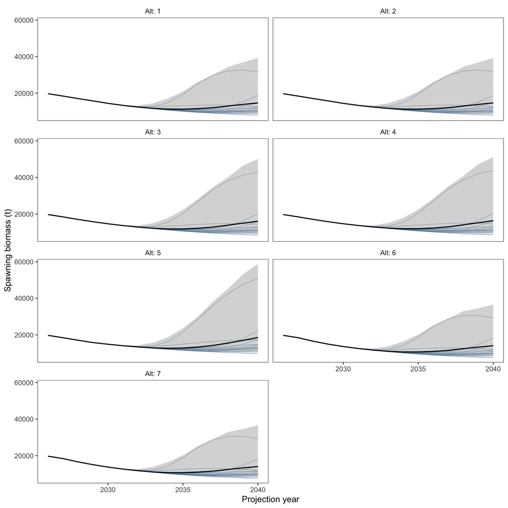

Figure 1: Conditional spawning biomass: 15 simulation paths per alternative, all-simulation median and 90% projection interval.

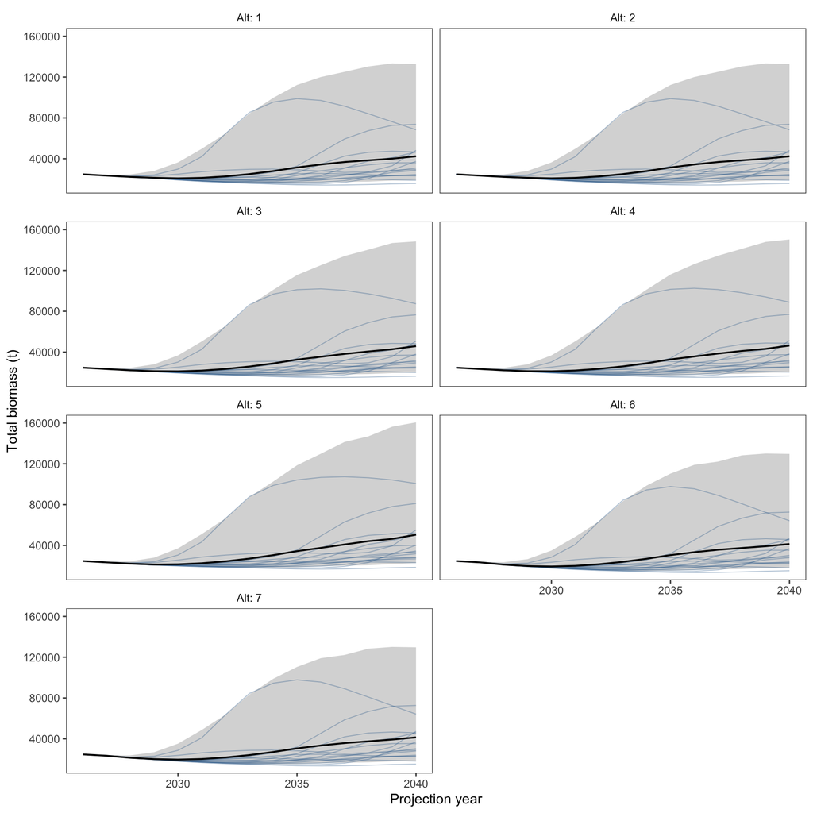

Figure 2: Conditional total population biomass under the saved run’s population-weight declarations.

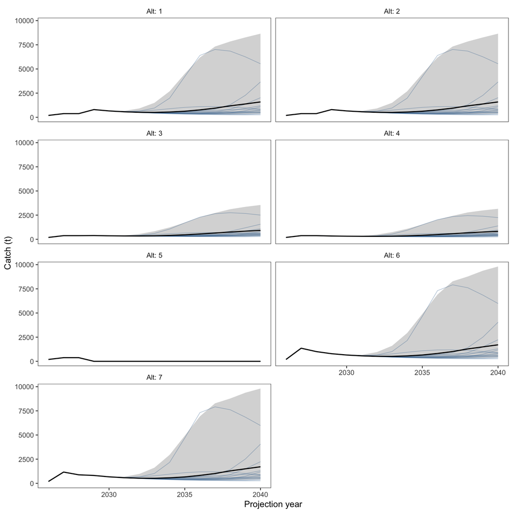

Figure 3: Conditional catch trajectories. Prescribed catches can make the 15 simulation paths overlap.

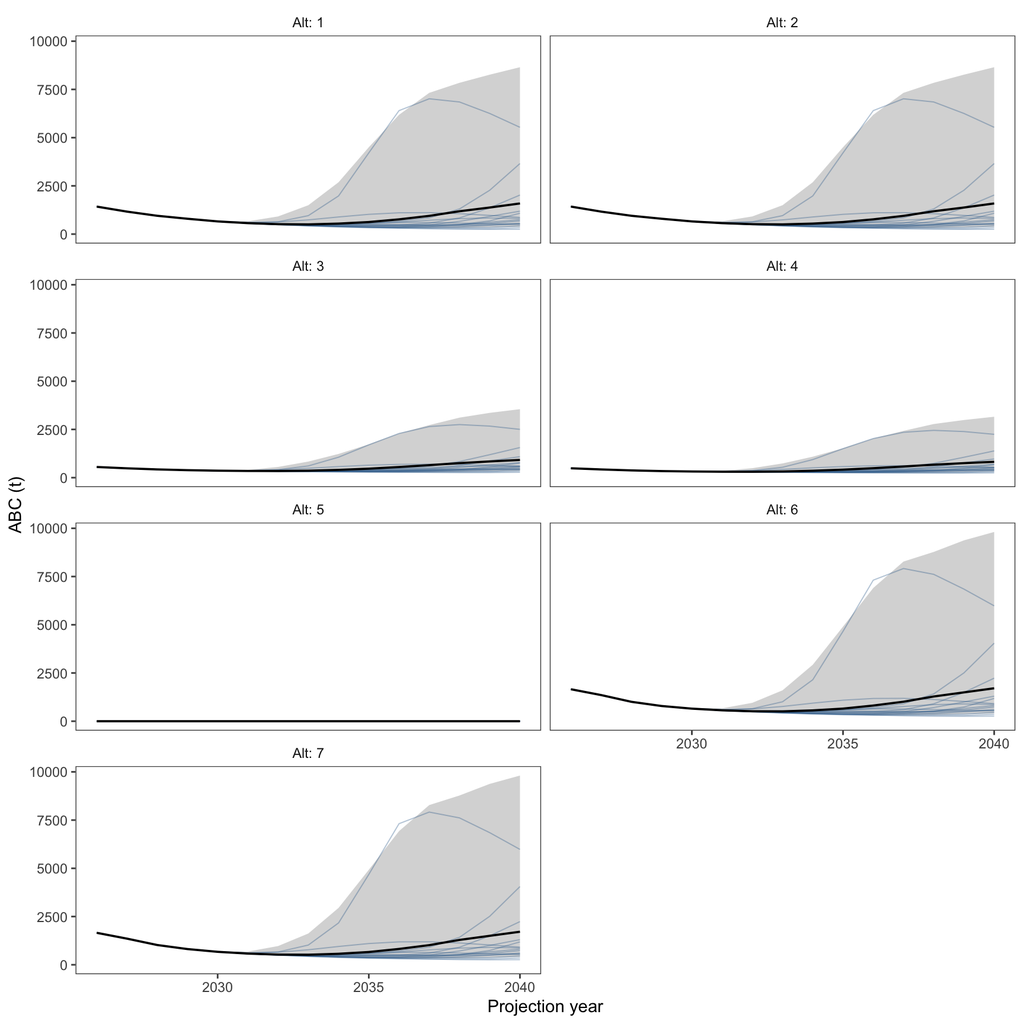

Figure 4: Conditional model ABC trajectories; these calculations are not adopted catch recommendations.

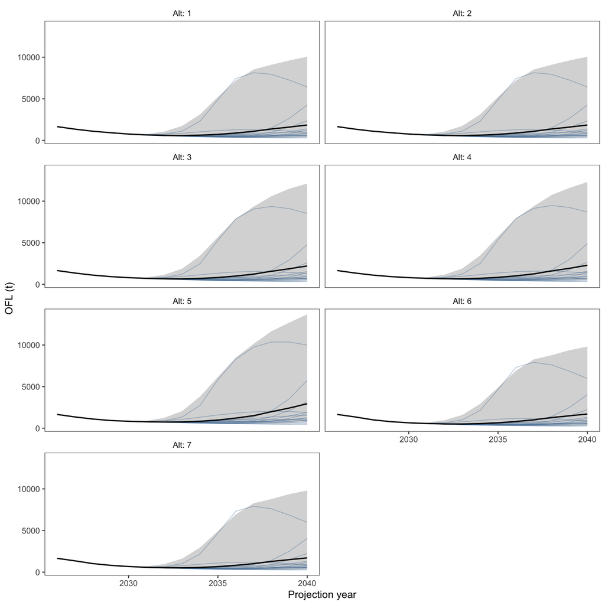

Figure 5: Conditional model OFL trajectories; scientific input review remains separate from successful execution.

## Summary tables

Tables use all simulations, not only the 15 displayed paths. They are recomputed from the hash-verified detailed output rather than an independently edited summary file. The first table covers the first 3 projection years; the second reports terminal-year distributions.

Conditional annual means by alternative for the first projection years. Units follow the saved run.

Conditional annual means — t

| Year | ABC | Catch | OFL | Spawning biomass | Total biomass |
| --- | --- | --- | --- | --- | --- |
| Alternative 1 |  |  |  |  |  |
| 2026 | 1,425.7 | 193.3 | 1,656.9 | 19,709.0 | 24,718.3 |
| 2027 | 1,165.5 | 378.0 | 1,355.3 | 18,413.7 | 23,478.4 |
| 2028 | 950.2 | 378.0 | 1,105.7 | 17,040.4 | 22,535.1 |
| Alternative 2 |  |  |  |  |  |
| 2026 | 1,425.7 | 193.3 | 1,656.9 | 19,709.0 | 24,718.3 |
| 2027 | 1,165.5 | 378.0 | 1,355.3 | 18,413.7 | 23,478.4 |
| 2028 | 950.2 | 378.0 | 1,105.7 | 17,040.4 | 22,535.1 |
| Alternative 3 |  |  |  |  |  |
| 2026 | 552.6 | 193.3 | 1,656.9 | 19,709.0 | 24,718.3 |
| 2027 | 484.1 | 378.0 | 1,355.3 | 18,413.7 | 23,478.4 |
| 2028 | 427.3 | 378.0 | 1,105.7 | 17,040.4 | 22,535.1 |
| Alternative 4 |  |  |  |  |  |
| 2026 | 486.3 | 193.3 | 1,656.9 | 19,709.0 | 24,718.3 |
| 2027 | 426.0 | 378.0 | 1,355.3 | 18,413.7 | 23,478.4 |
| 2028 | 376.0 | 378.0 | 1,105.7 | 17,040.4 | 22,535.1 |
| Alternative 5 |  |  |  |  |  |
| 2026 | 0.0 | 193.3 | 1,656.9 | 19,709.0 | 24,718.3 |
| 2027 | 0.0 | 378.0 | 1,355.3 | 18,413.7 | 23,478.4 |
| 2028 | 0.0 | 378.0 | 1,105.7 | 17,040.4 | 22,535.1 |
| Alternative 6 |  |  |  |  |  |
| 2026 | 1,656.9 | 193.3 | 1,656.9 | 19,709.0 | 24,718.3 |
| 2027 | 1,355.3 | 1,355.3 | 1,355.3 | 18,413.7 | 23,478.4 |
| 2028 | 1,006.4 | 1,006.4 | 1,006.4 | 16,479.2 | 21,594.9 |
| Alternative 7 |  |  |  |  |  |
| 2026 | 1,656.9 | 193.3 | 1,656.9 | 19,709.0 | 24,718.3 |
| 2027 | 1,355.3 | 1,165.5 | 1,355.3 | 18,413.7 | 23,478.4 |
| 2028 | 1,025.4 | 881.0 | 1,025.4 | 16,589.1 | 21,777.5 |

Terminal-year median and 5th–95th percentile projection range, using all simulations.

Terminal projection distributions — t

| Alternative | Year | Median | 5th percentile | 95th percentile |
| --- | --- | --- | --- | --- |
| ABC |  |  |  |  |
| 1 | 2040 | 1,588.5 | 377.3 | 8,650.8 |
| 2 | 2040 | 1,588.5 | 377.3 | 8,650.8 |
| 3 | 2040 | 918.5 | 361.3 | 3,550.0 |
| 4 | 2040 | 821.1 | 324.2 | 3,157.7 |
| 5 | 2040 | 0.0 | 0.0 | 0.0 |
| 6 | 2040 | 1,708.1 | 401.6 | 9,809.8 |
| 7 | 2040 | 1,712.7 | 404.5 | 9,808.3 |
| Catch |  |  |  |  |
| 1 | 2040 | 1,588.5 | 377.3 | 8,650.8 |
| 2 | 2040 | 1,588.5 | 377.3 | 8,650.8 |
| 3 | 2040 | 918.5 | 361.3 | 3,550.0 |
| 4 | 2040 | 821.1 | 324.2 | 3,157.7 |
| 5 | 2040 | 0.0 | 0.0 | 0.0 |
| 6 | 2040 | 1,708.1 | 401.6 | 9,809.8 |
| 7 | 2040 | 1,712.7 | 404.5 | 9,808.3 |
| OFL |  |  |  |  |
| 1 | 2040 | 1,849.7 | 440.2 | 10,054.5 |
| 2 | 2040 | 1,849.7 | 440.2 | 10,054.5 |
| 3 | 2040 | 2,205.8 | 496.3 | 12,107.5 |
| 4 | 2040 | 2,288.2 | 516.5 | 12,299.4 |
| 5 | 2040 | 2,942.8 | 702.2 | 13,690.3 |
| 6 | 2040 | 1,708.1 | 401.6 | 9,809.8 |
| 7 | 2040 | 1,712.7 | 404.5 | 9,808.3 |
| SSB |  |  |  |  |
| 1 | 2040 | 14,657.2 | 8,838.2 | 39,241.8 |
| 2 | 2040 | 14,657.2 | 8,838.2 | 39,241.8 |
| 3 | 2040 | 16,056.0 | 9,361.7 | 50,152.2 |
| 4 | 2040 | 16,354.8 | 9,525.4 | 51,128.5 |
| 5 | 2040 | 18,560.5 | 10,764.5 | 58,800.3 |
| 6 | 2040 | 14,008.4 | 8,390.9 | 36,611.5 |
| 7 | 2040 | 14,039.1 | 8,430.3 | 36,641.1 |
| Tot_biom |  |  |  |  |
| 1 | 2040 | 42,370.8 | 18,896.3 | 132,724.0 |
| 2 | 2040 | 42,370.8 | 18,896.3 | 132,724.0 |
| 3 | 2040 | 45,846.7 | 19,913.0 | 148,460.6 |
| 4 | 2040 | 46,393.4 | 20,229.6 | 150,348.6 |
| 5 | 2040 | 50,525.3 | 22,809.7 | 160,646.4 |
| 6 | 2040 | 41,395.2 | 18,313.2 | 129,705.4 |
| 7 | 2040 | 41,421.2 | 18,351.2 | 129,713.9 |

## Provenance and checks

The report requires a successful native exit and verifies recorded input, output and archived-source hashes before displaying a saved run. It checks result dimensions, alternative/year/simulation keys and finite nonnegative quantities. Current-source differences are labelled rather than overwritten. Historical-recruitment simulation fits no parameters: maximum-gradient and positive-definite-Hessian diagnostics are **not applicable** in this mode.

| Provenance | Recorded value |
| --- | --- |
| Selected directory | spmR_runs/attempt-001 |
| Run ID | 20261028T002324.463680-run-1525f5710750b |
| Completed UTC | 2026-10-28 00:23:26 UTC |
| spmR version at execution | 0.4.3 |
| Executable SHA-256 | c4ef7d1d00712f0ae7a497c8aca97ba3de6f251084ab8b2285e815e3b43bd559 |
| Population weights | Fratio-weighted fishery proxies |
| Scientific status | Conditional computational projection; SS3 export review remains open |

| Archived source | Matches current source |
| --- | --- |
| spm.dat | TRUE |
| ForProjections.dat | TRUE |
| tacpar.dat | TRUE |

**Current input fingerprints and rendering environment**

```
                                                           spm.dat
"304be0910ad4b499f23213d4033c6c92fdd9ba15f822efe177440aa7e64d3466"
                                                ForProjections.dat
"c59206cacc7485c43f2be7553ab764e5da871863fac0cb370c2e9310c4322506"
```